# NFL football play by play analysis of 2015

```r
install.packages("dummies")
install.packages("ggplot2")
install.packages("dummies")
install.packages("stringr")
install.packages("plyr")
```

```r
library(ggplot2)
library(data.table)
library(dummies)
library(stringr)
library(plyr)
```

```r
setwd("C:\\Users\\Owner\\Desktop\\gitstuff\\Projects\\nflPlayByPlay")
df <- read.csv(file = "NFLPlaybyPlay2015.csv", header=TRUE, sep=",", stringsAsFactors = FALSE)
df
```

| X | Date | GameID | Drive | qtr | down | time | TimeUnder | TimeSecs | PlayTimeDiff | SideofField | yrdln | yrdline100 | ydstogo | ydsnet | GoalToGo | FirstDown | posteam | DefensiveTeam | desc | PlayAttempted | Yards.Gained | sp | Touchdown | ExPointResult | TwoPointConv | DefTwoPoint | Safety | PuntResult | PlayType | … |
| --- | --- | --- | --- | --- | --- | --- | --- | --- | --- | --- | --- | --- | --- | --- | --- | --- | --- | --- | --- | --- | --- | --- | --- | --- | --- | --- | --- | --- | --- | --- |
| 36 | 2015-09-10 | 2015091000 | 1 | 1 | NA | 15:00 | 15 | 3600 | 0 | NE | 35 | 35 | 0 | 0 | 0 | NA | PIT | NE | S.Gostkowski kicks 65 yards from NE 35 to end zone, Touchback. | 1 | 0 | 0 | 0 | NA | NA | NA | 0 | NA | Kickoff | … |
| 51 | 2015-09-10 | 2015091000 | 1 | 1 | 1 | 15:00 | 15 | 3600 | 0 | PIT | 20 | 80 | 10 | 18 | 0 | 1 | PIT | NE | (15:00) De.Williams right tackle to PIT 38 for 18 yards (D.Hightower). | 1 | 18 | 0 | 0 | NA | NA | NA | 0 | NA | Run | … |
| 72 | 2015-09-10 | 2015091000 | 1 | 1 | 1 | 14:21 | 15 | 3561 | 39 | PIT | 38 | 62 | 10 | 31 | 0 | 0 | PIT | NE | (14:21) B.Roethlisberger pass short right to A.Brown pushed ob at PIT 47 for 9 yards (D.Hightower). | 1 | 9 | 0 | 0 | NA | NA | NA | 0 | NA | Pass | … |
| 101 | 2015-09-10 | 2015091000 | 1 | 1 | 2 | 14:04 | 15 | 3544 | 17 | PIT | 47 | 53 | 1 | 31 | 0 | 1 | PIT | NE | (14:04) De.Williams right guard to NE 49 for 4 yards (J.Collins; M.Brown). | 1 | 4 | 0 | 0 | NA | NA | NA | 0 | NA | Run | … |
| 122 | 2015-09-10 | 2015091000 | 1 | 1 | 1 | 13:26 | 14 | 3506 | 38 | NE | 49 | 49 | 10 | 45 | 0 | 1 | PIT | NE | (13:26) B.Roethlisberger pass short right to H.Miller to NE 35 for 14 yards (J.Mayo). | 1 | 14 | 0 | 0 | NA | NA | NA | 0 | NA | Pass | … |
| 159 | 2015-09-10 | 2015091000 | 1 | 1 | 1 | 12:42 | 13 | 3462 | 44 | NE | 35 | 35 | 10 | 56 | 0 | 1 | PIT | NE | (12:42) (Shotgun) De.Williams right guard to NE 24 for 11 yards (J.Collins). | 1 | 11 | 0 | 0 | NA | NA | NA | 0 | NA | Run | … |
| 180 | 2015-09-10 | 2015091000 | 1 | 1 | 1 | 12:05 | 13 | 3425 | 37 | NE | 24 | 24 | 10 | 48 | 0 | 0 | PIT | NE | (12:05) A.Brown sacked at NE 32 for -8 yards (M.Brown). | 1 | -8 | 0 | 0 | NA | NA | NA | 0 | NA | Sack | … |
| 199 | 2015-09-10 | 2015091000 | 1 | 1 | 2 | 11:20 | 12 | 3380 | 45 | NE | 32 | 32 | 18 | 54 | 0 | 0 | PIT | NE | (11:20) (Shotgun) De.Williams right end pushed ob at NE 28 for 4 yards (D.Hightower). PENALTY on PIT-M.Gilbert, Offensive Holding, 10 yards, enforced at NE 32 - No Play. | 1 | 4 | 0 | 0 | NA | NA | NA | 0 | NA | No Play | … |
| 236 | 2015-09-10 | 2015091000 | 1 | 1 | 2 | 10:53 | 11 | 3353 | 27 | NE | 42 | 42 | 28 | 54 | 0 | 0 | PIT | NE | (10:53) W.Johnson right guard to NE 36 for 6 yards (R.Ninkovich). NE-D.Easley was injured during the play. He is Out. | 1 | 6 | 0 | 0 | NA | NA | NA | 0 | NA | Run | … |
| 261 | 2015-09-10 | 2015091000 | 1 | 1 | 3 | 10:28 | 11 | 3328 | 25 | NE | 36 | 36 | 22 | 54 | 0 | 0 | PIT | NE | (10:28) (Shotgun) B.Roethlisberger pass short right to H.Miller to NE 26 for 10 yards (P.Chung; M.Butler). | 1 | 10 | 0 | 0 | NA | NA | NA | 0 | NA | Pass | … |

[output cut: 990 more lines]

Find the sum of all passing yards and rushing yards. What does this say about the league today?

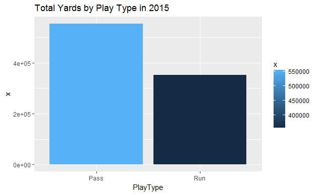

```r
totalYds<-aggregate(df$ydsnet, by=list(PlayType=df$PlayType), FUN = sum)
runPassTotalYds<-totalYds[totalYds$PlayType %in% c("Run","Pass"), ]
ggplot(runPassTotalYds, aes(PlayType, x, fill=x)) +
       geom_bar(position="dodge", stat = "identity") + ggtitle("Total Yards by Play Type in 2015")
```

What we see is that the NFL is primarily a passing league. Let’s look at quarterbacks.

```r
qbdf<-df[ which(!is.na(df$Passer)), ]
qbdf<- dummy.data.frame(qbdf, names = c("PassOutcome","PassLength","PassLocation","TwoPointConv") , sep = ".")
qbdf<- qbdf[, !(colnames(qbdf) %in% c("Rusher","RushAttempt","RunLocation","RunGap","FieldGoalResult","FieldGoalDistance","Challenge.Replay","ChalReplayResult","Accepted.Penalty","PenalizedTeam","PenaltyType","PenalizedPlayer","Penalty.Yards","Season","X","Date","time","desc","ExPointResult","PuntResult","Drive","GameID","qtr","TimeUnder","TimeSecs","PlayTimeDiff","SideofField","yrdln","yrdline100","ydstogo","GoalToGo","posteam","DefensiveTeam","PassLength.NA","PassLocation.NA","PosTeamScore","DefTeamScore","ScoreDiff","AbsScoreDiff","PlayType","Interceptor","TwoPointConv.NA","down.NA","sp","Receiver","ReturnResult","Returner","BlockingPlayer","Tackler1","Tackler2","RecFumbTeam","RecFumbPlayer","DefTwoPoint","Sack","down","ydsnet","Safety","PlayAttempted"))]
qbdt<-setDT(qbdf)
qbdt<-qbdt[, lapply(.SD, sum, na.rm=TRUE), by=Passer ]
qbdf<-setDF(qbdt)
qbdf1<-qbdf[qbdf$PassAttempt>=400, ]
qbdf1<-qbdf1[order(-qbdf1$Yards.Gained), ]
rownames(qbdf1) <- 1:nrow(qbdf1)
qbdf1
```

|  | Passer | FirstDown | Yards.Gained | Touchdown | TwoPointConv.Failure | TwoPointConv.Success | PassAttempt | PassOutcome.Complete | PassOutcome.Incomplete Pass | PassLength.Deep | PassLength.Short | PassLocation.left | PassLocation.middle | PassLocation.right | InterceptionThrown | Reception | Fumble |
| --- | --- | --- | --- | --- | --- | --- | --- | --- | --- | --- | --- | --- | --- | --- | --- | --- | --- |
| 1 | T.Brady | 220 | 5236 | 39 | 0 | 0 | 666 | 426 | 240 | 115 | 550 | 296 | 164 | 205 | 9 | 426 | 3 |
| 2 | D.Brees | 222 | 5030 | 35 | 1 | 0 | 666 | 446 | 220 | 130 | 518 | 257 | 144 | 247 | 13 | 446 | 7 |
| 3 | P.Rivers | 225 | 4971 | 35 | 1 | 2 | 714 | 461 | 253 | 107 | 599 | 274 | 177 | 255 | 15 | 461 | 9 |
| 4 | C.Palmer | 233 | 4891 | 35 | 0 | 0 | 574 | 351 | 223 | 151 | 423 | 196 | 143 | 235 | 12 | 351 | 5 |
| 5 | M.Ryan | 243 | 4740 | 25 | 1 | 1 | 657 | 428 | 229 | 89 | 565 | 242 | 192 | 220 | 17 | 428 | 6 |
| 6 | E.Manning | 207 | 4645 | 38 | 0 | 0 | 661 | 397 | 264 | 112 | 548 | 245 | 180 | 235 | 17 | 397 | 9 |
| 7 | B.Bortles | 207 | 4600 | 39 | 4 | 1 | 640 | 373 | 267 | 153 | 482 | 221 | 145 | 269 | 20 | 373 | 2 |
| 8 | M.Stafford | 213 | 4382 | 33 | 1 | 0 | 617 | 407 | 210 | 85 | 530 | 225 | 166 | 224 | 16 | 407 | 4 |
| 9 | K.Cousins | 191 | 4366 | 32 | 1 | 2 | 578 | 396 | 182 | 113 | 453 | 232 | 139 | 195 | 11 | 396 | 8 |
| 10 | R.Tannehill | 184 | 4339 | 26 | 1 | 1 | 619 | 379 | 240 | 127 | 489 | 222 | 124 | 270 | 12 | 379 | 6 |

[output cut: 15 more lines]

From looking at this data we see that generally the yards gained is greater than the yards for each quarterback in the 2015 season. The only thing I can attribute this too is the fact that penalty yards aren’t accounted for due to this. I think this is ok because we are trying to rate the passer himself and since the penalties of the team are rarely on the quarterback, penalty yards should not affect him.4

```r
passer<-qbdf$Passer
qbRushDF<-df[which(df$Rusher %in% passer), ]
qbRushDF<- dummy.data.frame(qbRushDF, names = c("RunLocation","RunGap") , sep = ".")
qbRushDF<- qbRushDF[, !(colnames(qbRushDF) %in% c("FieldGoalResult","FieldGoalDistance","Challenge.Replay","ChalReplayResult","Accepted.Penalty","PenalizedTeam","PenaltyType","PenalizedPlayer","Penalty.Yards","Season","X","Date","time","desc","ExPointResult","PuntResult","Drive","GameID","qtr","TimeUnder","TimeSecs","PlayTimeDiff","SideofField","yrdln","yrdline100","ydstogo","GoalToGo","posteam","DefensiveTeam","PosTeamScore","DefTeamScore","ScoreDiff","AbsScoreDiff","PlayType","Interceptor","TwoPointConv.NA","down.NA","sp","Receiver","ReturnResult","Returner","BlockingPlayer","Tackler1","Tackler2","RecFumbTeam","RecFumbPlayer","DefTwoPoint","Sack","down","ydsnet","Safety","PlayAttempted","Passer","PassAttempt","PassOutcome","PassLength","PassLocation","TwoPointConv","InterceptionThrown","RunLocation.NA","RunGap.NA","Reception"))]
qbRushDT<-setDT(qbRushDF)
qbRushDT<-qbRushDF[, lapply(.SD, sum, na.rm=TRUE), by=Rusher ]
qbRushDF<-setDF(qbRushDT)
qbRushDF<-rename(qbRushDF,c("Rusher"="Passer","Yards.Gained"="Rushing.Yards","Touchdown"="Rushing.Touchdown","FirstDown"="Rushing.FirstDown"))
qbRushDF
```

| Passer | Rushing.FirstDown | Rushing.Yards | Rushing.Touchdown | RushAttempt | RunLocation.left | RunLocation.middle | RunLocation.right | RunGap.end | RunGap.guard | RunGap.tackle | Fumble |
| --- | --- | --- | --- | --- | --- | --- | --- | --- | --- | --- | --- |
| T.Brady | 11 | 67 | 3 | 20 | 5 | 13 | 2 | 4 | 5 | 0 | 1 |
| J.Cutler | 16 | 207 | 1 | 31 | 13 | 2 | 14 | 17 | 6 | 4 | 3 |
| A.Rodgers | 19 | 356 | 1 | 46 | 13 | 11 | 21 | 29 | 6 | 1 | 1 |
| A.Smith | 23 | 500 | 2 | 75 | 23 | 27 | 22 | 38 | 2 | 5 | 2 |
| R.Mallett | 1 | 10 | 1 | 3 | 0 | 0 | 4 | 2 | 2 | 0 | 0 |
| J.Grimes | 9 | 281 | 1 | 56 | 10 | 25 | 21 | 10 | 13 | 8 | 0 |
| J.McCown | 10 | 99 | 1 | 19 | 5 | 5 | 7 | 8 | 3 | 1 | 3 |
| J.Manziel | 10 | 222 | 0 | 32 | 9 | 14 | 8 | 12 | 1 | 4 | 0 |
| R.Fitzpatrick | 21 | 288 | 2 | 47 | 11 | 20 | 13 | 17 | 4 | 3 | 3 |
| M.Cassel | 4 | 79 | 0 | 15 | 5 | 5 | 4 | 7 | 1 | 1 | 2 |

[output cut: 57 more lines]

```r
sackDF<-df[which(df$Sack==1), ]
rownames(sackDF) <- 1:nrow(sackDF)
for (i in 1:nrow(sackDF))
{
  if (length(passer[str_detect(sackDF[i, "desc"],passer)])!=0)
  {
   sackDF[i, "Passer"]<-passer[str_detect(sackDF[i, "desc"],passer)][1]
  }
}
sackDF<-sackDF[which(!is.na(sackDF$Passer)), ]
sackDF<-sackDF[, !(colnames(sackDF) %in% c("FieldGoalResult","FieldGoalDistance","Challenge.Replay","ChalReplayResult","Accepted.Penalty","PenalizedTeam","PenaltyType","PenalizedPlayer","Penalty.Yards","Season","X","Date","time","desc","ExPointResult","PuntResult","Drive","GameID","qtr","TimeUnder","TimeSecs","PlayTimeDiff","SideofField","yrdln","yrdline100","ydstogo","GoalToGo","posteam","DefensiveTeam","PosTeamScore","DefTeamScore","ScoreDiff","AbsScoreDiff","PlayType","Interceptor","TwoPointConv.NA","down.NA","sp","Receiver","ReturnResult","Returner","BlockingPlayer","Tackler1","Tackler2","RecFumbTeam","RecFumbPlayer","DefTwoPoint","down","ydsnet","Safety","PlayAttempted","Rusher","PassAttempt","PassOutcome","PassLength","PassLocation","TwoPointConv","InterceptionThrown","RunLocation.NA","RunGap.NA","Reception","Rusher","RushAttempt","RunLocation","RunGap","FirstDown","Touchdown","Yards.Gained"))]
sackdt<-setDT(sackDF)
sackdt<-sackdt[, lapply(.SD, sum, na.rm=TRUE), by=Passer ]
sackDF<-setDF(sackdt)
sackDF
```

| Passer | Fumble | Sack |
| --- | --- | --- |
| T.Brady | 5 | 40 |
| B.Roethlisberger | 0 | 21 |
| J.Cutler | 6 | 29 |
| A.Smith | 2 | 50 |
| B.Hoyer | 7 | 27 |
| R.Mallett | 1 | 7 |
| J.Manziel | 6 | 21 |
| A.Luck | 2 | 16 |
| K.Cousins | 4 | 28 |
| R.Tannehill | 10 | 48 |

[output cut: 52 more lines]

```r
qbdf<-rename(qbdf,c("Yards.Gained"="Passing.Yards","Touchdown"="Passing.Touchdown","FirstDown"="Passing.FirstDown"))
qbdf
```

| Passer | Passing.FirstDown | Passing.Yards | Passing.Touchdown | TwoPointConv.Failure | TwoPointConv.Success | PassAttempt | PassOutcome.Complete | PassOutcome.Incomplete Pass | PassLength.Deep | PassLength.Short | PassLocation.left | PassLocation.middle | PassLocation.right | InterceptionThrown | Reception | Fumble |
| --- | --- | --- | --- | --- | --- | --- | --- | --- | --- | --- | --- | --- | --- | --- | --- | --- |
| B.Roethlisberger | 178 | 4160 | 22 | 2 | 8 | 515 | 342 | 173 | 126 | 379 | 186 | 134 | 185 | 17 | 342 | 3 |
| T.Brady | 220 | 5236 | 39 | 0 | 0 | 666 | 426 | 240 | 115 | 550 | 296 | 164 | 205 | 9 | 426 | 3 |
| J.Cutler | 166 | 3772 | 25 | 2 | 1 | 510 | 323 | 187 | 101 | 405 | 194 | 64 | 248 | 12 | 323 | 4 |
| A.Rodgers | 186 | 3998 | 32 | 1 | 4 | 640 | 366 | 274 | 136 | 497 | 242 | 141 | 250 | 9 | 366 | 5 |
| A.Smith | 149 | 3684 | 22 | 1 | 1 | 500 | 321 | 179 | 66 | 431 | 165 | 109 | 223 | 8 | 321 | 5 |
| B.Hoyer | 125 | 2724 | 22 | 1 | 0 | 388 | 229 | 159 | 71 | 316 | 157 | 92 | 138 | 8 | 229 | 3 |
| R.Mallett | 91 | 1410 | 6 | 0 | 1 | 253 | 137 | 116 | 40 | 212 | 92 | 69 | 91 | 6 | 137 | 2 |
| R.Fitzpatrick | 186 | 3986 | 31 | 0 | 0 | 582 | 339 | 243 | 145 | 437 | 243 | 125 | 214 | 15 | 339 | 7 |
| J.McCown | 96 | 2210 | 14 | 1 | 2 | 316 | 194 | 122 | 51 | 260 | 106 | 70 | 135 | 5 | 194 | 2 |
| J.Manziel | 75 | 1506 | 7 | 0 | 0 | 229 | 132 | 97 | 36 | 192 | 96 | 41 | 91 | 5 | 132 | 3 |

[output cut: 76 more lines]

```r
newqbdf<-merge(x = qbdf, y = qbRushDF, by = "Passer", all.y = TRUE)
newqbdf$Fumble<-newqbdf$Fumble.x+newqbdf$Fumble.y
newqbdf<-newqbdf[, !(colnames(newqbdf) %in% c("Fumble.y","Fumble.x","Reception"))]
newqbdf<-merge(x = newqbdf, y = sackDF, by = "Passer", all.x = TRUE)
newqbdf$Fumble<-newqbdf$Fumble.x+newqbdf$Fumble.y
newqbdf<-newqbdf[, !(colnames(newqbdf) %in% c("Fumble.y","Fumble.x"))]
newqbdf<-newqbdf[newqbdf$PassAttempt>=300, ]
newqbdf$Plays<-newqbdf$PassAttempt+newqbdf$RushAttempt+newqbdf$Sack
newqbdf<-newqbdf[!is.na(newqbdf$Passer), ]
newqbdf
```

|  | Passer | Passing.FirstDown | Passing.Yards | Passing.Touchdown | TwoPointConv.Failure | TwoPointConv.Success | PassAttempt | PassOutcome.Complete | PassOutcome.Incomplete Pass | PassLength.Deep | PassLength.Short | PassLocation.left | PassLocation.middle | PassLocation.right | InterceptionThrown | Rushing.FirstDown | Rushing.Yards | Rushing.Touchdown | RushAttempt | RunLocation.left | RunLocation.middle | RunLocation.right | RunGap.end | RunGap.guard | RunGap.tackle | Sack | Fumble | Plays |
| --- | --- | --- | --- | --- | --- | --- | --- | --- | --- | --- | --- | --- | --- | --- | --- | --- | --- | --- | --- | --- | --- | --- | --- | --- | --- | --- | --- | --- |
| 2 | A.Dalton | 150 | 3436 | 28 | 1 | 0 | 416 | 265 | 151 | 100 | 314 | 130 | 100 | 184 | 7 | 9 | 153 | 3 | 46 | 6 | 20 | 15 | 14 | 6 | 1 | 19 | 11 | 481 |
| 4 | A.Luck | 95 | 2049 | 15 | 1 | 1 | 306 | 172 | 134 | 72 | 232 | 115 | 60 | 129 | 12 | 14 | 191 | 0 | 27 | 7 | 11 | 8 | 10 | 1 | 4 | 16 | 4 | 349 |
| 6 | A.Rodgers | 186 | 3998 | 32 | 1 | 4 | 640 | 366 | 274 | 136 | 497 | 242 | 141 | 250 | 9 | 19 | 356 | 1 | 46 | 13 | 11 | 21 | 29 | 6 | 1 | 50 | 15 | 736 |
| 7 | A.Smith | 149 | 3684 | 22 | 1 | 1 | 500 | 321 | 179 | 66 | 431 | 165 | 109 | 223 | 8 | 23 | 500 | 2 | 75 | 23 | 27 | 22 | 38 | 2 | 5 | 50 | 9 | 625 |
| 8 | B.Bortles | 207 | 4600 | 39 | 4 | 1 | 640 | 373 | 267 | 153 | 482 | 221 | 145 | 269 | 20 | 18 | 301 | 4 | 44 | 18 | 12 | 9 | 25 | 2 | 0 | 53 | 17 | 737 |
| 11 | B.Hoyer | 125 | 2724 | 22 | 1 | 0 | 388 | 229 | 159 | 71 | 316 | 157 | 92 | 138 | 8 | 6 | 52 | 0 | 7 | 2 | 5 | 0 | 1 | 0 | 1 | 27 | 10 | 422 |
| 13 | B.Roethlisberger | 178 | 4160 | 22 | 2 | 8 | 515 | 342 | 173 | 126 | 379 | 186 | 134 | 185 | 17 | 4 | 38 | 0 | 6 | 0 | 4 | 2 | 1 | 1 | 0 | 21 | 4 | 542 |
| 18 | C.Newton | 179 | 3939 | 35 | 0 | 0 | 521 | 301 | 220 | 115 | 405 | 221 | 94 | 205 | 11 | 49 | 666 | 9 | 118 | 38 | 32 | 44 | 49 | 19 | 14 | 36 | 10 | 675 |
| 19 | C.Palmer | 233 | 4891 | 35 | 0 | 0 | 574 | 351 | 223 | 151 | 423 | 196 | 143 | 235 | 12 | 3 | 40 | 2 | 8 | 3 | 4 | 0 | 2 | 1 | 0 | 28 | 12 | 610 |
| 23 | D.Brees | 222 | 5030 | 35 | 1 | 0 | 666 | 446 | 220 | 130 | 518 | 257 | 144 | 247 | 13 | 4 | 30 | 1 | 8 | 1 | 5 | 2 | 2 | 1 | 0 | 35 | 12 | 709 |

[output cut: 19 more lines]

```r
anotherQBDF<-data.frame(row.names = newqbdf$Passer)
anotherQBDF$completionRatio<-newqbdf$PassOutcome.Complete/newqbdf$PassAttempt
anotherQBDF$passingYardsPerComp<-newqbdf$Passing.Yards/newqbdf$PassOutcome.Complete
anotherQBDF$passingYardsPerAttempt<-newqbdf$Passing.Yards/newqbdf$PassAttempt
anotherQBDF$rushingYardsPerAttempt<-newqbdf$Rushing.Yards/newqbdf$RushAttempt
anotherQBDF$passFirstDownPerComp<-newqbdf$Passing.FirstDown/newqbdf$PassOutcome.Complete
anotherQBDF$rushFirstDownPerAttempt<-newqbdf$Rushing.FirstDown/newqbdf$RushAttempt
anotherQBDF$passingTouchdownPerComp<-newqbdf$Passing.Touchdown/newqbdf$PassOutcome.Complete
anotherQBDF$rushingTouchdownPerAttempt<-newqbdf$Rushing.Touchdown/newqbdf$RushAttempt
anotherQBDF$shortPassRatio<-newqbdf$PassLength.Short/newqbdf$PassAttempt
anotherQBDF$deepPassRatio<-newqbdf$PassLength.Deep/newqbdf$PassAttempt
anotherQBDF$fumblePerPlay<-newqbdf$Fumble/newqbdf$Plays
anotherQBDF$sackPerPlay<-newqbdf$Sack/newqbdf$Plays
anotherQBDF$interceptionPerAttempt<-newqbdf$InterceptionThrown/newqbdf$PassAttempt
anotherQBDF
```

|  | completionRatio | passingYardsPerComp | passingYardsPerAttempt | rushingYardsPerAttempt | passFirstDownPerComp | rushFirstDownPerAttempt | passingTouchdownPerComp | rushingTouchdownPerAttempt | shortPassRatio | deepPassRatio | fumblePerPlay | sackPerPlay | interceptionPerAttempt |
| --- | --- | --- | --- | --- | --- | --- | --- | --- | --- | --- | --- | --- | --- |
| A.Dalton | 0.6370192 | 12.96604 | 8.259615 | 3.326087 | 0.5660377 | 0.19565217 | 0.10566038 | 0.06521739 | 0.7548077 | 0.2403846 | 0.022869023 | 0.03950104 | 0.01682692 |
| A.Luck | 0.5620915 | 11.91279 | 6.696078 | 7.074074 | 0.5523256 | 0.51851852 | 0.08720930 | 0.00000000 | 0.7581699 | 0.2352941 | 0.011461318 | 0.04584527 | 0.03921569 |
| A.Rodgers | 0.5718750 | 10.92350 | 6.246875 | 7.739130 | 0.5081967 | 0.41304348 | 0.08743169 | 0.02173913 | 0.7765625 | 0.2125000 | 0.020380435 | 0.06793478 | 0.01406250 |
| A.Smith | 0.6420000 | 11.47664 | 7.368000 | 6.666667 | 0.4641745 | 0.30666667 | 0.06853583 | 0.02666667 | 0.8620000 | 0.1320000 | 0.014400000 | 0.08000000 | 0.01600000 |
| B.Bortles | 0.5828125 | 12.33244 | 7.187500 | 6.840909 | 0.5549598 | 0.40909091 | 0.10455764 | 0.09090909 | 0.7531250 | 0.2390625 | 0.023066486 | 0.07191316 | 0.03125000 |
| B.Hoyer | 0.5902062 | 11.89520 | 7.020619 | 7.428571 | 0.5458515 | 0.85714286 | 0.09606987 | 0.00000000 | 0.8144330 | 0.1829897 | 0.023696682 | 0.06398104 | 0.02061856 |
| B.Roethlisberger | 0.6640777 | 12.16374 | 8.077670 | 6.333333 | 0.5204678 | 0.66666667 | 0.06432749 | 0.00000000 | 0.7359223 | 0.2446602 | 0.007380074 | 0.03874539 | 0.03300971 |
| C.Newton | 0.5777351 | 13.08638 | 7.560461 | 5.644068 | 0.5946844 | 0.41525424 | 0.11627907 | 0.07627119 | 0.7773512 | 0.2207294 | 0.014814815 | 0.05333333 | 0.02111324 |
| C.Palmer | 0.6114983 | 13.93447 | 8.520906 | 5.000000 | 0.6638177 | 0.37500000 | 0.09971510 | 0.25000000 | 0.7369338 | 0.2630662 | 0.019672131 | 0.04590164 | 0.02090592 |
| D.Brees | 0.6696697 | 11.27803 | 7.552553 | 3.750000 | 0.4977578 | 0.50000000 | 0.07847534 | 0.12500000 | 0.7777778 | 0.1951952 | 0.016925247 | 0.04936530 | 0.01951952 |

[output cut: 19 more lines]